# Using causaleffect and igraph

Cory Whitney

## Using igraph

Make a causal map with igraph. For example the notation X -+ Z identifies and draws a directed edge (a causal arrow) from X to Z. These can be words or phrases but this does not look very good yet and we probably need to do a bit of work learning and ‘hacking’ igraph if we want these to be very verbose text boxes.

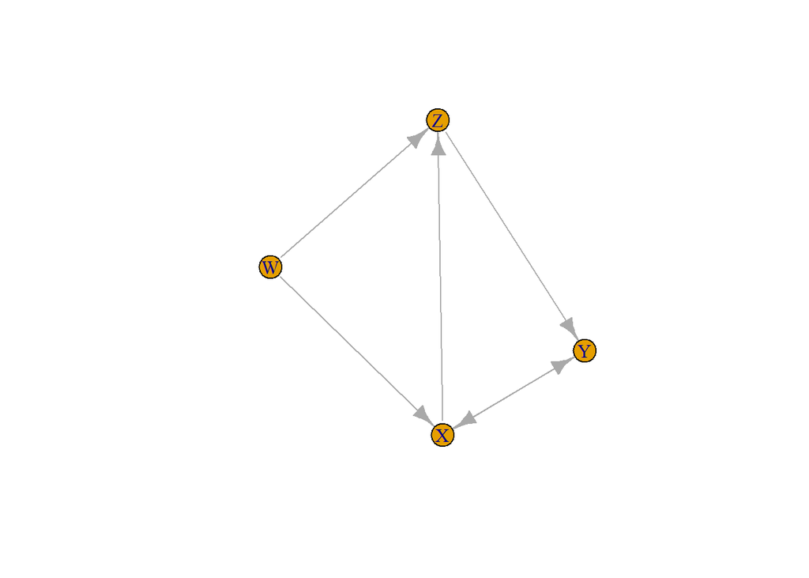

```r
fig1 <- graph.formula(W -+ X, W -+ Z, X -+ Z, Z -+ Y, X -+ Y, Y -+ X, simplify = FALSE)

plot(fig1)
```

The fifth and sixth arrow of the “graph.formula” (connecting X and Y) are bidirected. We therefore have to add the following “set.edge.attribute” command:

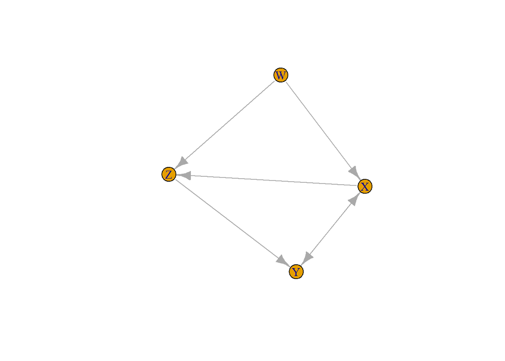

```r
fig1_ammend <- set.edge.attribute(graph = fig1, name = "description", index = c(5,6), value = "U")

plot(fig1_ammend)
```

## Using causaleffect

Get a mathmatical expression for the ‘interventional distribution’ (do-Calculus) using the causal.effect function.

```r
ce1 <- causal.effect(y = "Y", x = "X", z = NULL, G = fig1_ammend, expr = TRUE)

ce1
```

```
## [1] "\\sum_{W,Z}\\left(\\sum_{X}P(Y|W,X,Z)P(X|W)\\right)P(Z|W,X)P(W)"
```

The result of this function is readable in Latex. We can replace the double slash ‘\’ with a single ‘' so that it is also readable in Rmarkdown when wrapped in’$’ symbols in R markdown results in a LateX formula look like this:

$\sum_{W,Z}\left(\sum_{X}P(Y|W,X,Z)P(X|W)\right)P(Z|W,X)P(W)$

Or we can avoid that manual work and use the ‘Concatenate and Print’ `cat()` function.

```r
cat(ce1)
```

```
## \sum_{W,Z}\left(\sum_{X}P(Y|W,X,Z)P(X|W)\right)P(Z|W,X)P(W)
```

$\sum_{W,Z}\left(\sum_{X}P(Y|W,X,Z)P(X|W)\right)P(Z|W,X)P(W)$